# Surpassing the R vs Python dogma

May 2019

## Contents

- Background - why we are talking about it
- Ways of closing the gap
  - Feather
  - Apache Arrow
  - Ursa Labs
  - Rstudio 1.2 / reticulated python
- Conclusion

## Background

- There is an argument in the data science space
- Can be observed by countless articles / blog posts etc on R vs Python
- **BUT**: this argument is not very helpful and divisive
- Focus should be on the task at hand, not the tools
  - you can drill a hole with a hammer, but it won’t be elegant
- Both tools have strengths and weaknesses (not part of this talk)
- You are here to solve a problem, not to have a favourite algorithm or tool

## Reality check

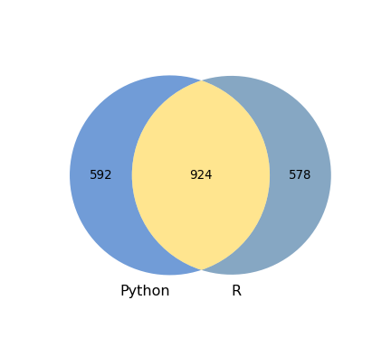

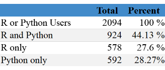

## What Python and R have in common

- A lot of data science teams use both
- both languages have rich interfaces to C / C++
- most of under-the-hood coding is done in C / C++

**Would it not make sense to aim for interoperability?**

## Feather

- Python and R use data frames as a fundamental data structure
  - Pandas data frame are based on the idea of R’s data frames
- Implemented after the announcement of Apache Arrow
  - Aim: share data between Python and R
  - Use a binary file format for data frames
  - bridge time until Apache Arrow is implemented
- Uses the Apache Arrow columnar specification to represent binary data **on disk** (zero-copy access)
- Fast, lightweight, and easy-to-use binary file format for storing data frames.
- High read and write performance.

## Limitations of Feather

- Quickly exchange data between Python and R code, however it’s not designed for long-term data storage.
- Supports limited scalar value types, adequate only for representing typical data found in R and pandas
- Supports only a single batch of rows (no ability to append to existing files)
- Only non-nested data types and categorical (dictionary-encoded) types are supported

## Apache Arrow

A standarised, language-independent representation of in-memory columnar data

- Exchange data without conversion between the different languages including python and R (also C, C++, C#, Go, Java, JavaScript, MATLAB, Ruby, and Rust.)
- Zero-copy dataflow
- Optimised for analytic purposes
- Supports flat and nested format and conveniently many native data types
- Backed by key developers of 13 major open source projects (including Cassandra, Hadoop, HBase, Parquet, Spark, … )

## Apache Arrow

source: arrow.apache.org

[figure not shown]

- Each system has its own internal memory format
- All systems utilize the same memory format
- 70-80% computation wasted on serialization and deserialization
- No overhead for cross-system communication
- Similar functionaltiy implemented in multiple projects
- Projects can share functionality

## Ursa Labs

When to comes to the most fundamental tasks (data access, data manipulation, data analysis, ……. ), data science tools are not optimised to make use of state-of-the-art hardware, as the efforts has been mainly focused on machine learning problems.

- Ursa Labs is an organisation founded
  - by Wes McKinney (and Hadley Wickham as advisor for R)
  - with the goal of advancing open source, cross-language software for data scientists
- Focuses on the data science tools of the Apache Arrow Project (Arrow has a broader application scope)
- May expand to create software artifacts focused more specifically on the data science domain

## Rstudio 1.2 / reticulated python

### The package: reticulate

- Reticulate is an R package that makes it possible to embed a Python session within an R process.
- Provides wrapper functions to use python modules and scripts
  - import, python_source, repl_python, use_python, py_install, ……
- Data conversion back and forth between the two languages happens through C++
- R and Python variables are accessible from both environments
  - The objects py and r provide this access

## Type conversion

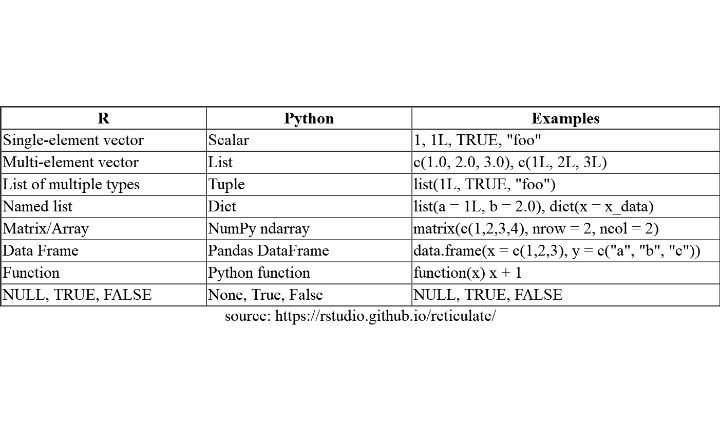

## Rstudio 1.2 / reticulated python

### The IDE: Rstudio 1.2

- Automatic access to a python REPL when stepping into a python script
  - read–eval–print loop
  - interactive language shell
  - simple, interactive computer programming environment
- Line-by-line execution of Python code
- Support for Python syntax highlighting
- Autocompletion and Inline help for Python …… HOOORAY!!!
- R notebooks with Python code chunks
- Automatic switch in the code history pane between Python and R
- Sourcing full Python scripts
- Display of matplotlib plots within the plots pane in RStudio and inline in the notebooks

## R Notebooks

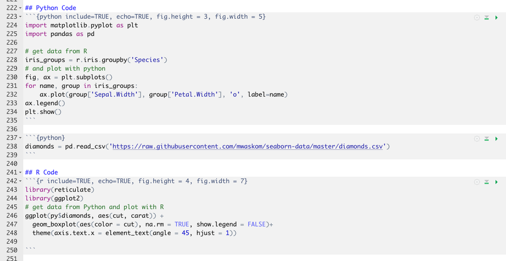

## Python Code

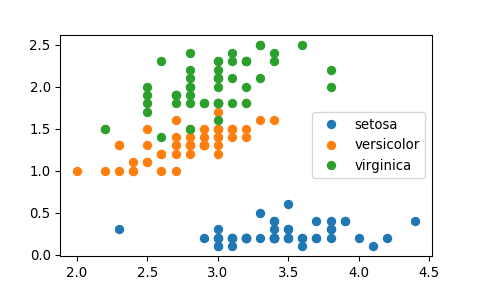

```python
import matplotlib.pyplot as plt
import pandas as pd
# get data from R
iris_groups = r.iris.groupby('Species')
# and plot with python
fig, ax = plt.subplots()
for name, group in iris_groups:
    ax.plot(group['Sepal.Width'], group['Petal.Width'], 'o', label=name)
ax.legend()
plt.show()
```

## R Code

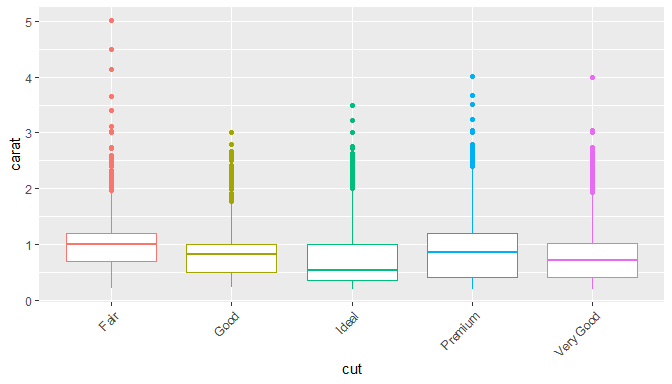

```r
library(reticulate)
library(ggplot2)
# get data from Python and plot with R
ggplot(py$diamonds, aes(cut, carat)) +
  geom_boxplot(aes(color = cut), na.rm = TRUE, show.legend = FALSE)+
  theme(axis.text.x = element_text(angle = 45, hjust = 1))
```

## Is RStudio a good alternative as a Python IDE?

- It makes switching from R to Python certainly easier
- It supports syntax highlighting and autocomplete
- It is not intended as a Python IDE (yet?)
- Since it’s slightly painful, it’s probably a Python IDE for data science though ;)

## Conclusion

- R *vs* Python is now R *and* Python
  - It’s not about the tool, it’s about the task at hand
- There are many initiatives to bring the tools closer together
  - Ursa labs => Apache Arrow
  - RStudio => Python integration
- The dogmatic war was boring before it started
- This is the time to start to embrace the strengths of the tools and to collaborate

## Questions?

## Sources

- https://towardsdatascience.com/from-r-vs-python-to-r-and-python-aa25db33ce17
- https://www.kdnuggets.com/2017/06/ecosystem-data-science-machine-learning-software.html/2
- http://ursalabs.org/tech/
- http://wesmckinney.com/blog/feather-arrow-future/
- https://arrow.apache.org/